# UAA2017_analysis

# Dependencies

```r
library(dplyr)    # data management
library(ggplot2)  # plotting
library(RColorBrewer)
library(broom)    # tidy output
library(Hmisc)    # spearmans rho correlations
```

# Analysis Plan

This notebook includes a-spatial statistics for three different areal units as a check against the modifable areal unit problem.

All crime data are handled as rates per 1,000 residents. For wards and neighborhoods, barriers are normalized using square miles. They do not need to be normalized for the grids because each grid is 1,000 meters square (approximately the size of a Census Block Group).

Population data have been interpolated (see Taylor’s method note) from Census Tracts using ACS 2010-2015 5-year esimates.

# Analysis by Grid Square

Read in raw data:

```r
grids <- read.csv("STL_BARRIERS_Grids_UAA2017.csv", stringsAsFactors = FALSE)
grids <- rename(grids, BarrierCount = BarrierCou)
```

Create crime rate variables that gauge crime per grid square relative to the square’s population:

```r
grids <- grids %>%
  mutate(crimeRate = (crime2016/pop15)*1000) %>%
  mutate(ucr1_4_Rate = (ucr1_4/pop15)*1000) %>%
  mutate(ucr1_8_Rate = (ucr1_8/pop15)*1000) %>%
  mutate(propRate = (propCrime1/pop15)*1000) %>%
  mutate(gridGTZero = ifelse(BarrierCount > 0, TRUE, FALSE))
```

Number of grid squares with and without barriers:

```r
summary(grids$gridGTZero)
```

```
   Mode   FALSE    TRUE    NA's
logical     147      68       0
```

Histogram for main study variable:

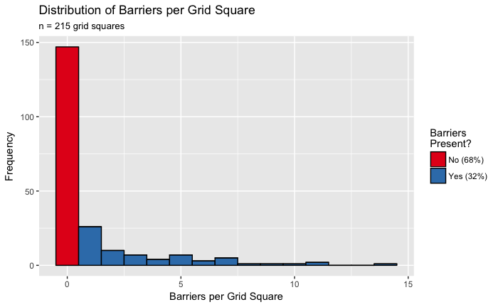

```r
gridPlot <- ggplot(grids, aes(BarrierCount, fill = gridGTZero)) +
  geom_histogram(binwidth = 1, color="black") +
  scale_fill_brewer(palette="Set1",
                    labels = c("No (68%)", "Yes (32%)"),
                    guide = guide_legend(title = "Barriers \nPresent?")) +
  labs(title = "Distribution of Barriers per Grid Square",
       subtitle = "n = 215 grid squares",
       x = "Barriers per Grid Square",
       y = "Frequency")
ggsave("gridPlot.png", width = 6.5, height = 4.75, units = "in")
gridPlot
```

Descriptive statistics for main study variable:

```r
summary(grids$BarrierCount)
```

```
   Min. 1st Qu.  Median    Mean 3rd Qu.    Max.
  0.000   0.000   0.000   1.088   1.000  14.000
```

Normality test of main study variable:

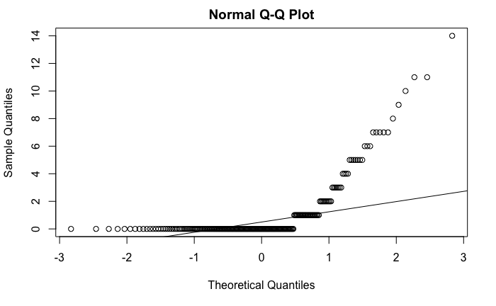

```r
qqnorm(grids$BarrierCount); qqline(grids$BarrierCount)
```

The q-q plot shows a highly skewed distirubtion, so we’ll use spearman’s rho for our correlation analysis:

```r
gridCorr <- grids %>%
  select(crimeRate, ucr1_4_Rate, ucr1_8_Rate, propRate, per_pov, per_blk, BarrierCount) %>%
  as.matrix()
gridResults <- tidy(rcorr(gridCorr, type="spearman"))
gridResults$p.value <- format(gridResults$p.value, scientific = FALSE)
gridResults <- filter(gridResults, column2 == "BarrierCount")
write.csv(gridResults, "gridResults.csv")
gridResults
```

| column1 | column2 | estimate | n | p.value |
| --- | --- | --- | --- | --- |
| crimeRate | BarrierCount | 0.4008838 | 215 | 0.00000000104953246 |
| ucr1_4_Rate | BarrierCount | 0.4405097 | 215 | 0.00000000001279821 |
| ucr1_8_Rate | BarrierCount | 0.4173146 | 215 | 0.00000000018095192 |
| propRate | BarrierCount | 0.3983608 | 215 | 0.00000000136329348 |
| per_pov | BarrierCount | 0.2513857 | 215 | 0.00019567289212530 |
| per_blk | BarrierCount | 0.2338524 | 215 | 0.00054618679198914 |

The main outcomes are the correlations between barrier counts and the crime and demographic variables. There are moderate, positive, statistically significant relationships between crime and barrier counts - the greater the number of barriers per grid square, the higher the crime rate generally is.

You can see that relationship here:

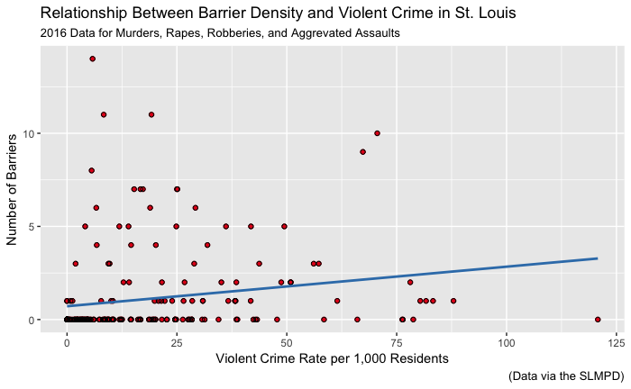

```r
gridViolent <- ggplot(grids, aes(ucr1_4_Rate, BarrierCount)) +
  geom_point(color = "#e41a1c") +
  geom_point(shape = 1, color = "black") +
  geom_smooth(method=lm, se=FALSE, color = "#377eb8") +
  labs(title = "Relationship Between Barrier Density and Violent Crime in St. Louis",
       subtitle = "2016 Data for Murders, Rapes, Robberies, and Aggrevated Assaults",
       x = "Violent Crime Rate per 1,000 Residents",
       y = "Number of Barriers",
       caption = "(Data via the SLMPD)")
ggsave("gridViolent.png", width = 6.5, height = 4.75, units = "in")
gridViolent
```

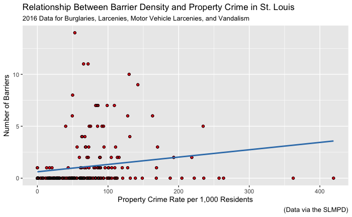

```r
gridProp <- ggplot(grids, aes(propRate, BarrierCount)) +
  geom_point(color = "#e41a1c") +
  geom_point(shape = 1, color = "black") +
  geom_smooth(method=lm, se=FALSE, color = "#377eb8") +
  labs(title = "Relationship Between Barrier Density and Property Crime in St. Louis",
       subtitle = "2016 Data for Burglaries, Larcenies, Motor Vehicle Larcenies, and Vandalism",
       x = "Property Crime Rate per 1,000 Residents",
       y = "Number of Barriers",
       caption = "(Data via the SLMPD)")
ggsave("gridProp.png", width = 6.5, height = 4.75, units = "in")
gridProp
```

Descriptive statistics output:

```r
a <- tidy(summary(grids$BarrierCount))
a <- mutate(a, variable = "barrier count")
b <- tidy(summary(grids$crimeRate))
b <- mutate(b, variable = "crime rate")
c <- tidy(summary(grids$ucr1_4_Rate))
c <- mutate(c, variable = "violent crimes")
d <- tidy(summary(grids$ucr1_8_Rate))
d <- mutate(d, variable = "part 1 crimes")
e <- tidy(summary(grids$propRate))
e <- mutate(e, variable = "property crimes")
f <- tidy(summary(grids$per_pov))
f <- mutate(f, variable = "poverty rate")
g <- tidy(summary(grids$per_blk))
g <- mutate(g, variable = "percent black")
gridStats <- bind_rows(a, b)
rm(a)
rm(b)
gridStats <- bind_rows(gridStats, c)
rm(c)
gridStats <- bind_rows(gridStats, d)
rm(d)
gridStats <- bind_rows(gridStats, e)
rm(e)
gridStats <- bind_rows(gridStats, f)
rm(f)
gridStats <- bind_rows(gridStats, g)
rm(g)
gridStats <- select(gridStats, variable, minimum, q1, median, mean, q3, maximum)
write.csv(gridStats, "gridStats.csv")
```

# Analysis by Ward

Read in raw data:

```r
wards <- read.csv("STL_BARRIERS_Wards10_UAA2017.csv", stringsAsFactors = FALSE)
wards <- rename(wards, BarrierCount = BarrierCou)
```

Create crime rate variables that gauge crime per ward relative to the wards’s population and a barrier rate that gauges the number of barriers per sq mile:

```r
wards <- wards %>%
  mutate(crimeRate = (crime2016/pop15)*1000) %>%
  mutate(ucr1_4_Rate = (ucr1_4/pop15)*1000) %>%
  mutate(ucr1_8_Rate = (ucr1_8/pop15)*1000) %>%
  mutate(propRate = (propCrime1/pop15)*1000) %>%
  mutate(barrierRate = (BarrierCount/sqmile))
```

Histogram for main study variable:

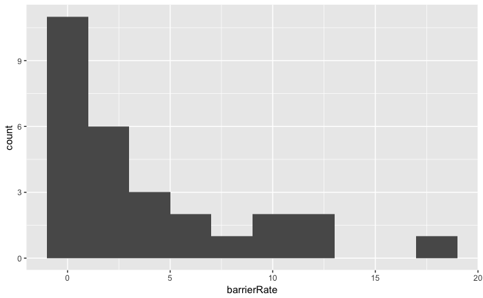

```r
wardPlot <- ggplot(wards, aes(barrierRate)) +
  geom_histogram(binwidth = 2)
wardPlot
```

Descriptive statistics for main study variable:

```r
summary(wards$barrierRate)
```

```
   Min. 1st Qu.  Median    Mean 3rd Qu.    Max.
  0.000   0.000   2.287   3.963   6.602  18.300
```

```r
wardsCorr <- wards %>%
  select(crimeRate, ucr1_4_Rate, ucr1_8_Rate, propRate, per_pov, per_blk, barrierRate) %>%
  as.matrix()
wardsResults <- cor(wardsCorr, method="kendall")
wardsResults
```

```
            crimeRate ucr1_4_Rate ucr1_8_Rate  propRate   per_pov   per_blk barrierRate
crimeRate   1.0000000   0.7777778   0.9365079 0.8518519 0.6507937 0.5925926   0.3354130
ucr1_4_Rate 0.7777778   1.0000000   0.7671958 0.6296296 0.7566138 0.7089947   0.3299144
ucr1_8_Rate 0.9365079   0.7671958   1.0000000 0.8624339 0.6402116 0.5820106   0.3574073
propRate    0.8518519   0.6296296   0.8624339 1.0000000 0.5555556 0.4761905   0.3903988
per_pov     0.6507937   0.7566138   0.6402116 0.5555556 1.0000000 0.6455026   0.3574073
per_blk     0.5925926   0.7089947   0.5820106 0.4761905 0.6455026 1.0000000   0.3684045
barrierRate 0.3354130   0.3299144   0.3574073 0.3903988 0.3574073 0.3684045   1.0000000
```

This analysis has generally similar findings to the grids analysis - there is a moderate (though a week moderate), positive relationship between the density of barriers per square mile and the crime rate.

# Analysis by Neighborhood

Read in raw data:

```r
nhood <- read.csv("STL_BARRIERS_Nhood_UAA2017.csv", stringsAsFactors = FALSE)
nhood <- rename(nhood, BarrierCount = BarrierCou)
```

```r
nhood <- nhood %>%
  mutate(crimeRate = (crime2016/pop15)*1000) %>%
  mutate(ucr1_4_Rate = (ucr1_4/pop15)*1000) %>%
  mutate(ucr1_8_Rate = (ucr1_8/pop15)*1000) %>%
  mutate(propRate = (propCrime1/pop15)*1000) %>%
  mutate(barrierRate = (BarrierCount/sqmile))
```

Histogram for main study variable:

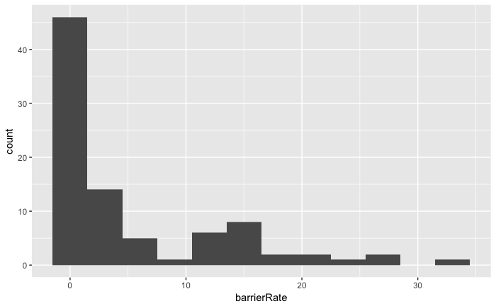

```r
nhoodPlot <- ggplot(nhood, aes(barrierRate)) +
  geom_histogram(binwidth = 3)
nhoodPlot
```

Descriptive statistics for main study variable:

```r
summary(nhood$barrierRate)
```

```
   Min. 1st Qu.  Median    Mean 3rd Qu.    Max.
  0.000   0.000   1.126   5.211  10.110  31.950
```

Normality test of main study variable:

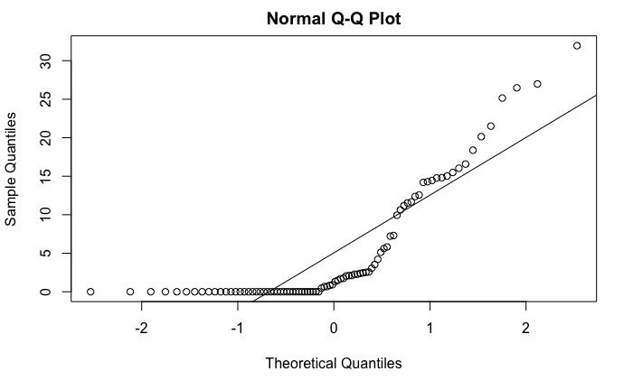

```r
qqnorm(nhood$barrierRate); qqline(nhood$barrierRate)
```

The q-q plot shows a highly skewed distirubtion, so we’ll use spearman’s rho for our correlation analysis:

```r
nhoodCorr <- nhood %>%
  select(crimeRate, ucr1_4_Rate, ucr1_8_Rate, propRate, per_pov, per_blk, barrierRate) %>%
  as.matrix()
nhoodCorr <- tidy(rcorr(nhoodCorr, type="spearman"))
nhoodCorr$p.value <- format(nhoodCorr$p.value, scientific = FALSE)
nhoodCorr
```

|  | column1 | column2 | estimate | n | p.value |
| --- | --- | --- | --- | --- | --- |
| 8 | crimeRate | ucr1_4_Rate | 0.9076948 | 88 | 0.0000000000000000000000 |
| 15 | crimeRate | ucr1_8_Rate | 0.9859639 | 88 | 0.0000000000000000000000 |
| 16 | ucr1_4_Rate | ucr1_8_Rate | 0.8850643 | 88 | 0.0000000000000000000000 |
| 22 | crimeRate | propRate | 0.9393822 | 88 | 0.0000000000000000000000 |
| 23 | ucr1_4_Rate | propRate | 0.7704764 | 88 | 0.0000000000000000000000 |
| 24 | ucr1_8_Rate | propRate | 0.9633863 | 88 | 0.0000000000000000000000 |
| 29 | crimeRate | per_pov | 0.5642105 | 88 | 0.0000000103652124661124 |
| 30 | ucr1_4_Rate | per_pov | 0.7281036 | 88 | 0.0000000000000008881784 |
| 31 | ucr1_8_Rate | per_pov | 0.5220492 | 88 | 0.0000001825196884741587 |
| 32 | propRate | per_pov | 0.4140044 | 88 | 0.0000608107871018503943 |

[output cut: 11 more lines]

This analysis has generally similar findings to the grids analysis - there is a moderate, positive relationship between the density of barriers per square mile and the crime rate. These coefficients are just a bit larger in terms of effect size than the grid analysis.

# Main Takeaways

Regardless of how we conceptualize our areal units, we see a moderate, positive relationship between barrier density and crime rate. This relationship is weakest at the ward and strongest at the neighborhood, with the relationship at the grid level just a bit weaker than the neighborhood level.

These findings run counter to the logic of the barriers, which suggests that barriers will decrease crime.

What they do not address, however, is the “island in the storm” phenomenon - are individual streets safter than the surroudning neighborhood if they have a barrier on them.